# DN1 Anja Trobec

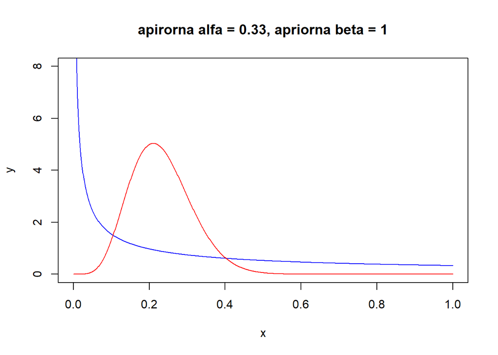

```r
risi_apriorna(alfa,beta)
risi_aposteriorna(alfa,beta)
```

```r
#3. MOZNOST:

alfa <- 9
beta <- 27


ocena_pricakovane_vrednosti(alfa,beta)
```

```
## [1] 0.2419
```

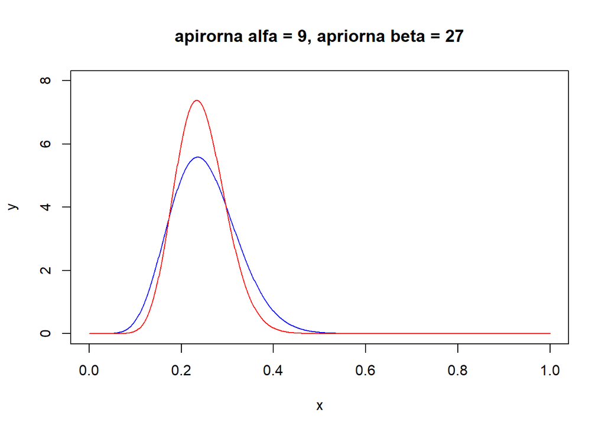

```r
risi_apriorna(alfa,beta)
risi_aposteriorna(alfa,beta)
```

```r
#4. MOZNOST

alfa <- 30
beta <- 90


ocena_pricakovane_vrednosti(alfa,beta)
```

```
## [1] 0.2466
```

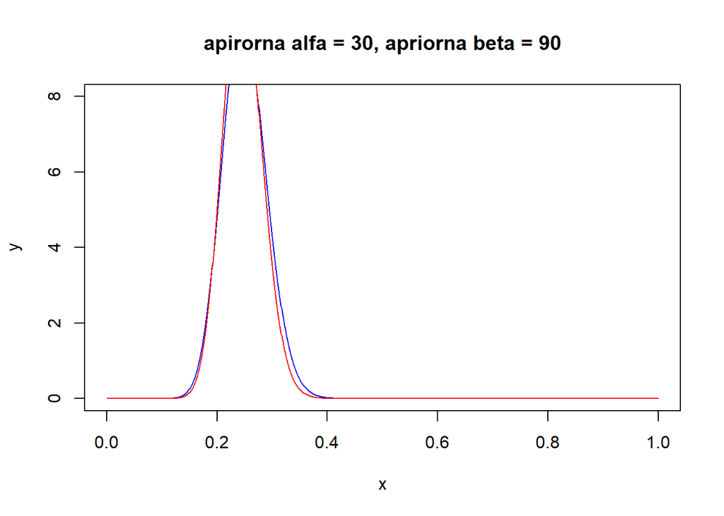

```r
risi_apriorna(alfa,beta)
risi_aposteriorna(alfa,beta)
```

```r
ugotovitev <- paste('Vidimo, da za dovolj velike alfe in bete je aposteriorna porazdelitev zelo blizu apriorne.')
print(ugotovitev)
```

```
## [1] "Vidimo, da za dovolj velike alfe in bete je aposteriorna porazdelitev zelo blizu apriorne."
```

```r
#5. MOZNOST

alfa <- 0.01
beta <- 0.03


ocena_pricakovane_vrednosti(alfa,beta)
```

```
## [1] 0.2308
```

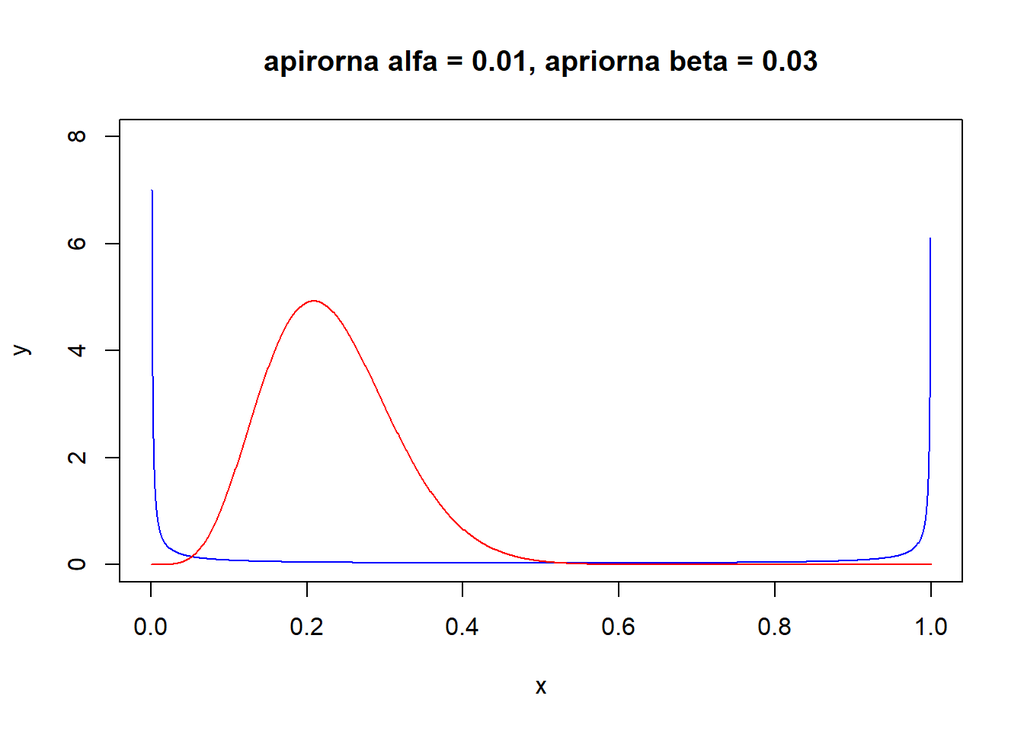

```r
risi_apriorna(alfa,beta)
risi_aposteriorna(alfa,beta)
```

```r
#SIMULACIJA ZA NAKLJUCNE ALFE IN BETE Z UPOSTEVANJEM RAZMERJA B<-3*A, BREZ RISANJA GOSTOT (samo v namen racunanja ocenjene povprecne ocene)

vsota <- 0
for(i in 1:50){
  a <- round(runif(1, 0, 100),2)
  b <- 3 * a
  a_post <- a + k
  b_post <- b + n - k
  ocena_pricakovane_vrednosti <- round(a_post / (a_post + b_post),4)
  vsota <- vsota + ocena_pricakovane_vrednosti
  izpisi <- paste(as.character(i),":",
        "alfa<-", as.character(a),",",
        "beta<-", as.character(b), ",",
        "alfa apost<-", as.character(a_post),",",
        "beta apost<-", as.character(b_post),",",
        "ocena pric. vr.<-", as.character(ocena_pricakovane_vrednosti), sep<-"")
  print(izpisi)

}
```

```
## [1] "1 : alfa<- 52.83 , beta<- 158.49 , alfa apost<- 58.83 , beta apost<- 178.49 , ocena pric. vr.<- 0.2479 "
## [1] "2 : alfa<- 55.35 , beta<- 166.05 , alfa apost<- 61.35 , beta apost<- 186.05 , ocena pric. vr.<- 0.248 "
## [1] "3 : alfa<- 15.54 , beta<- 46.62 , alfa apost<- 21.54 , beta apost<- 66.62 , ocena pric. vr.<- 0.2443 "
## [1] "4 : alfa<- 2.36 , beta<- 7.08 , alfa apost<- 8.36 , beta apost<- 27.08 , ocena pric. vr.<- 0.2359 "
## [1] "5 : alfa<- 50.3 , beta<- 150.9 , alfa apost<- 56.3 , beta apost<- 170.9 , ocena pric. vr.<- 0.2478 "
## [1] "6 : alfa<- 54.87 , beta<- 164.61 , alfa apost<- 60.87 , beta apost<- 184.61 , ocena pric. vr.<- 0.248 "
## [1] "7 : alfa<- 95.91 , beta<- 287.73 , alfa apost<- 101.91 , beta apost<- 307.73 , ocena pric. vr.<- 0.2488 "
## [1] "8 : alfa<- 26.59 , beta<- 79.77 , alfa apost<- 32.59 , beta apost<- 99.77 , ocena pric. vr.<- 0.2462 "
## [1] "9 : alfa<- 68.92 , beta<- 206.76 , alfa apost<- 74.92 , beta apost<- 226.76 , ocena pric. vr.<- 0.2483 "
## [1] "10 : alfa<- 38.56 , beta<- 115.68 , alfa apost<- 44.56 , beta apost<- 135.68 , ocena pric. vr.<- 0.2472 "
## [1] "11 : alfa<- 64.51 , beta<- 193.53 , alfa apost<- 70.51 , beta apost<- 213.53 , ocena pric. vr.<- 0.2482 "
## [1] "12 : alfa<- 30.3 , beta<- 90.9 , alfa apost<- 36.3 , beta apost<- 110.9 , ocena pric. vr.<- 0.2466 "
## [1] "13 : alfa<- 94.84 , beta<- 284.52 , alfa apost<- 100.84 , beta apost<- 304.52 , ocena pric. vr.<- 0.2488 "
## [1] "14 : alfa<- 86.06 , beta<- 258.18 , alfa apost<- 92.06 , beta apost<- 278.18 , ocena pric. vr.<- 0.2486 "
## [1] "15 : alfa<- 93.75 , beta<- 281.25 , alfa apost<- 99.75 , beta apost<- 301.25 , ocena pric. vr.<- 0.2488 "
```

[output cut: 35 more lines]

```r
povprecna_ocena_pricakovane_vrednosti <- round(vsota/50,4)
print(povprecna_ocena_pricakovane_vrednosti)
```

```
## [1] 0.2465
```

```r
ugotovitev <- paste("Ugotovimo, da ne glede na izbiro alf in bet v danem razmerju 1:3 velja, da je ocena pricakovane vrednosti ves cas priblizno okoli 0,24.")

print(ugotovitev)
```

```
## [1] "Ugotovimo, da ne glede na izbiro alf in bet v danem razmerju 1:3 velja, da je ocena pricakovane vrednosti ves cas priblizno okoli 0,24."
```

3. NALOGA

Denimo, da vzamemo nov vzorec studentov velikosti 30, ki so tudi odgovorili na prvotno vprasanje iz prve vaje. Izmed podanih 30 odgovorov je bilo 21 pravilnih. Privzemite neinformativno apriorno porazdelitev (Beta(1,1)) in izracunajte aposteriorno porazdelitev.

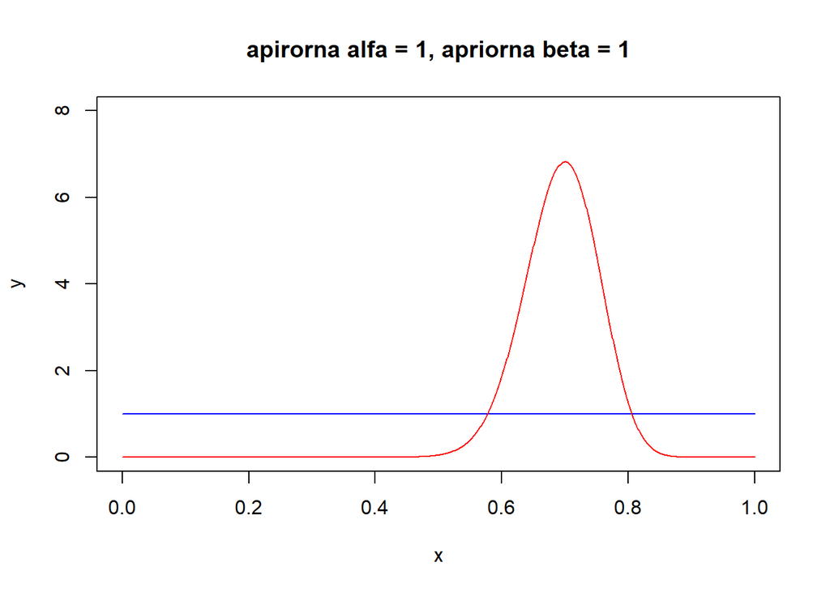

```r
n <- 30
k <- 21

a <- 1
b <- 1
aprior <- dbeta(x, a, b)

a_apost <- a + k
b_apost <- b + n - k
aposter <- dbeta(x, a_apost, b_apost)

risi_apriorna(a,b)
risi_aposteriorna(a_apost,b_apost)
```

```r
povprecna_vrednost_apost <- a_apost/(a_apost + b_apost)
print(povprecna_vrednost_apost)
```

```
## [1] 0.6875
```

4. NALOGA

Zelimo primerjati aposteriorno porazdelitev iz tocke 3 (oznacimo jo Z1) z aposteriorno porazdelitvijo, ki smo jo izracunali na vajah (Beta(7, 21) oznacimo jo Z2). Za ta namen lahko izracunamo verjetnost P(Z2 < Z1). To verjetnost lahko izracunamo direktno,lahko pa jo tudi ocenimo s pomocjo simulacije. Generirajte 10 000 vrednosti iz obeh aposteriornih porazdelitev (pomagajte si s funkcijo rbeta) na podlagi katerih ocenite verjetnost P(Z2 < Z1). Koliko znasa ocenjena verjetnost? Zapisite cenilko, ki ste jo uporabili. Izracunajte se 95% interval zaupanja na podlagi simulacije - kot 95% interval zaupanja lahko porocate 2,5% in 97,5% kvantil simuliranih podatkov (funkcija quantile).

```r
z1 <- dbeta(x, a_apost, b_apost)
z2 <- dbeta(x, 7, 21)


#simulacija
n <- 10000
v1 <- sort(rbeta(n, a_apost, b_apost, ncp = 0))
v2 <- sort(rbeta(n, 7, 21, ncp = 0))

drzi <- 0
for(i in 1:10000){
  if(v1[i] > v2[i]){
    drzi = drzi + 1
  }
}
print(drzi)
```

```
## [1] 10000
```

```r
ocenjena_vrednost <- drzi/10000

print(ocenjena_vrednost)
```

```
## [1] 1
```

```r
#frekventistična cenilka: ugodni izidi / vsemi poskusi


#INTERVAL ZAUPANJA
L1 <- round(v1[250],5)
U1 <- round(v1[9750],5)

IZ1 = paste("Interval zaupanja 1 (za alfa_apost = 22, beta_apost = 10): [", as.character(L1), ",", as.character(U1), "]", sep="")



L2 <- round(v2[250],5)
U2 <- round(v2[9750],5)

IZ2 = paste("Interval zaupanja 2 (za alfa_apost = 7, beta_apost = 21) : [", as.character(L2), ",", as.character(U2), "]", sep="")

print(IZ1)
```

```
## [1] "Interval zaupanja 1 (za alfa_apost = 22, beta_apost = 10): [0.51773,0.83181]"
```

```r
print(IZ2)
```

```
## [1] "Interval zaupanja 2 (za alfa_apost = 7, beta_apost = 21) : [0.11116,0.42184]"
```